# Project 1

Author

Mubin Ejaz

# Code Base:

#### TextFile manupulation:

I will be starting out by saving the .txt provided to the same folder as the project. I’ll use the read_lines(“textfilename”) function of tidyverse/dplyr to read in the text file. I noticed the pattern of the text file to have the following pattern:  
dash row —->row 1 (I ended up stripping this one off the bat)  
header —–>row 1  
header ——>row 2  
dash row —–>row 3  
player data—>row 4  
player data —>row 5  
dash row—>row 6  
player data—–>row 7  
player data——>row 8  
dash row —–>row 9  
Row 1 to row 3 can now just simply be stripped away by declaring a new variable and start saving it from line 4 of the txt file.

I also can use str_split and use | as a delimiter to break the rows into columns.  
Trying to display playerDataFrame and ratingsDataFram was giving me error. Upon google search, I realize they were still just list of strings and characters the **as.data.frame(do.call(rbind, playerDataFrame))** would help me convert them into actual data frames that I can then manipulate.  
I’ll have to play around with the code to see which combination of join/ select/mutate would give me a better structure that I can then output using write_csv().

## Code Chunks Tried

```r
library(tidyverse)
library(readr)
library(knitr)
library(DT)
```

```r
#reading the text file in.
TextFile <- read_lines("tournamentinfo.txt")

#declaring TF as a character tibble. This is where structured TextFile will be saved
TF <- character()

#counter variable
counter <- 1

#length of TextFile, would help me loop through the raw TextFile
lf <- length(TextFile)

#looping through TextFile from 1 to end row of the TextFile
while (counter <= lf) {
  #stripping the first row of dashes
  if (!str_detect(TextFile[counter], "^\\s*-+\\s*$")) {
    TF <- c(TF, str_sub(TextFile[counter],2, str_length(TextFile[counter])-1))
  }

  counter <- counter + 1
}

r<-1

#will split the user data vs ratings data.
playerDataFrame<-character()
ratingsDataFram<-character()

lf<-length(TF)
n<-3
i<-1
j<-1

#looping through and splitting rows into different dataframes
while(lf){
  if(n %% 2 == 1){
    playerDataFrame[i]<-TF[n]
    i<-i+1

  }
  else if(n%% 2 == 0){
    ratingsDataFram[j]<-TF[n]
    j<-j+1
  }
  n=n+1
  lf=lf-1
}

n<-1
r<-1
while(r<length(playerDataFrame)){
  playerDataFrame[r]<-str_split(playerDataFrame[r], "\\|")
  r<-r+1
}

n<-1
r<-1
while(r<length(playerDataFrame)){
  ratingsDataFram[r]<-str_split(ratingsDataFram[r], "\\|")
  r<-r+1
}


#Trying to display playerDataFrame and ratingsDataFram was giving me error. Upon
#google search, i realize they were still just list of strings and characters
# the as.data.frame(do.call(rbind, playerDataFrame)) would help me convert them into
#data frames that I can then manipulate

playerDataFrame<-as.data.frame(do.call(rbind, playerDataFrame))
ratingsDataFram<-as.data.frame(do.call(rbind, ratingsDataFram))

ratingsDataFram <- ratingsDataFram %>%
  mutate(PlayerNumber = row_number())


playerDataFrame <- playerDataFrame %>%
  mutate(V1 = as.integer(V1))

combinedData <- playerDataFrame %>%
  left_join(
    ratingsDataFram,
    by = c("V1" = "PlayerNumber")
  )

combinedData <- combinedData |>
  mutate(PreRating = as.numeric(str_extract(str_extract(V2.y, "R:\\s*\\d+"), "\\d+")))

selectiveData<-combinedData|> select('Name' = V2.x, 'Total Points'=V3.x, 'State' = V1.y, "User's PreRating"= PreRating)
```

```r
opponents <- combinedData |>
  select(V1, V4.x:V10.x) |>
  pivot_longer(
    cols = V4.x:V10.x,
    names_to = "Round",
    values_to = "Result"
  )
opponents <- opponents |>
  mutate(Opponent = as.integer(str_extract(Result, "\\d+")))

opponentRatings <- opponents |>
  left_join(
    combinedData |>
      select(V1, PreRating),
    by = c("Opponent" = "V1")
  )
```

Now calculating average and saving as integer.

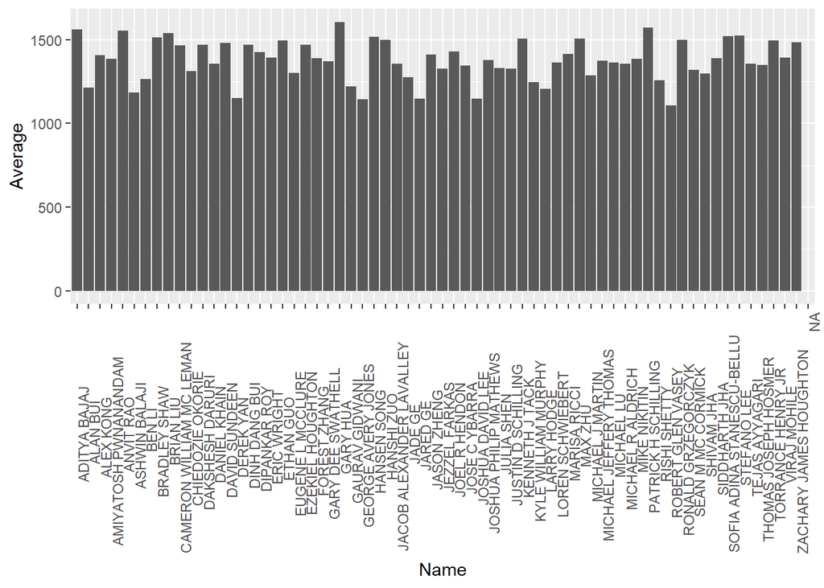

```r
averageRatings <- opponentRatings |>
  group_by(V1) |>
  summarise(
    Average = as.integer(mean(PreRating, na.rm = TRUE))

  )

selectiveData <- combinedData |>
  left_join(averageRatings, by = c("V1" = "V1")) |>
  select(Name = V2.x,`Total Points` = V3.x,State = V1.y,`Pre Rating` = PreRating,
    Average = Average
  )
write.csv(selectiveData, "ChessTournament.csv")
ggplot(selectiveData, aes(x = Name, y = Average)) +
  geom_col() +
  theme(axis.text.x = element_text(angle = 90, hjust = 1))
```